# CFA Practice V1

Author

firdaus

# 1 Preliminaries

## 1.1 Load Library

```r
library(readxl)
library(foreign)
library(psych)
library(lavaan)  # for CFA
library(semTools)  # for additional functions in SEM
library(semPlot)  # for path diagram
```

## 1.2 Load Data

```r
data1 = read_excel("CFA_Practice_V1.xlsx")
names(data1)
```

```
 [1] "P1"  "P2"  "P3"  "P4"  "P5"  "P6"  "P7"  "P8"  "P9"  "P10" "P11" "P12"
[13] "P13" "P14" "P15" "P16" "P17" "P18" "P19" "P20" "P21" "P22"
```

```r
head(data1)
```

```
# A tibble: 6 × 22
  P1     P2    P3    P4    P5    P6    P7    P8    P9    P10   P11   P12   P13
  <chr>  <chr> <chr> <chr> <chr> <chr> <chr> <chr> <chr> <chr> <chr> <chr> <chr>
1 Selalu Sela… Sela… Sela… Sent… Sent… Sela… Sela… Sela… Sent… Sent… Sent… Sent…
2 Tidak… Kada… Kada… Sela… Jara… Sela… Sela… Sela… Sela… Sent… Sent… Sent… Sent…
3 Jarang Sent… Sent… Sent… Sent… Sela… Sela… Kada… Sela… Sela… Sela… Sela… Kada…
4 Jarang Jara… Jara… Jara… Jara… Jara… Jara… Jara… Jara… Kada… Kada… Kada… Kada…
5 Jarang Sela… Sela… Kada… Sela… Jara… Kada… Jara… Sela… Kada… Sela… Sela… Sela…
6 Senti… Sent… Sent… Sent… Kada… Sent… Sent… Sent… Sent… Sent… Sent… Sent… Sent…
# ℹ 9 more variables: P14 <chr>, P15 <chr>, P16 <chr>, P17 <chr>, P18 <chr>,
#   P19 <chr>, P20 <chr>, P21 <chr>, P22 <chr>
```

```r
dim(data1)
```

```
[1] 201  22
```

Coding the answers

```r
# Define mapping function
likert_map <- function(x) {
  recode <- c(
    "Tidak pernah" = 1,
    "Jarang"        = 2,
    "Kadang-kadang"         = 3,
    "Selalu"              = 4,
    "Sentiasa"       = 5
  )
  recode[match(tolower(x), tolower(names(recode)))]
}

# Apply transformation from data1 -> data2
data2 <- data1

for (col in names(data2)) {
  data2[[col]] <- likert_map(data2[[col]])
}

# Convert all to numeric
data2 <- as.data.frame(lapply(data2, as.numeric))
```

From EFA, we include only good items across PA1 till PA3.

PA1 (Teaching Practices) : P1, P2, P3, P4, P5, P6, P7, P8, P9, P16, P17 (11 item)

PA2 (Monitoring) : P10, P11, P12, P13, P14 (5 item)

PA3 (Involvement): P15, P18, P19, P20, P21, P22 (6 item)

```r
data.cfa = data2[c("P1", "P2","P3", "P4", "P5", "P6", "P7", "P8", "P9", "P10", "P11", "P12", "P13", "P14", "P15", "P16", "P17", "P18", "P19", "P20", "P21", "P22")]
```

```r
str(data.cfa)
```

```
'data.frame':   201 obs. of  22 variables:
 $ P1 : num  4 1 2 2 2 5 2 1 3 3 ...
 $ P2 : num  4 3 5 2 4 5 3 5 4 5 ...
 $ P3 : num  4 3 5 2 4 5 3 5 4 5 ...
 $ P4 : num  4 4 5 2 3 5 3 5 4 5 ...
 $ P5 : num  5 2 5 2 4 3 1 5 4 5 ...
 $ P6 : num  5 4 4 2 2 5 1 5 4 5 ...
 $ P7 : num  4 4 4 2 3 5 4 5 4 5 ...
 $ P8 : num  4 4 3 2 2 5 4 4 3 3 ...
 $ P9 : num  4 4 4 2 4 5 4 4 4 5 ...
 $ P10: num  5 5 4 3 3 5 4 5 4 5 ...
 $ P11: num  5 5 4 3 4 5 4 5 4 5 ...
 $ P12: num  5 5 4 3 4 5 4 5 4 5 ...
 $ P13: num  5 5 3 3 4 5 4 5 4 5 ...
 $ P14: num  5 5 5 3 3 5 1 5 4 5 ...
 $ P15: num  5 5 5 3 4 5 5 5 4 5 ...
 $ P16: num  5 5 5 3 3 5 5 5 4 5 ...
 $ P17: num  5 5 5 3 3 5 3 5 4 5 ...
 $ P18: num  5 5 5 3 4 5 4 1 4 5 ...
 $ P19: num  5 5 5 3 2 5 4 3 3 3 ...
 $ P20: num  5 5 5 3 3 5 4 1 4 5 ...
 $ P21: num  5 5 5 3 4 5 2 1 3 5 ...
 $ P22: num  5 5 4 3 3 5 2 5 4 5 ...
```

```r
dim(data.cfa)
```

```
[1] 201  22
```

```r
names(data.cfa)
```

```
 [1] "P1"  "P2"  "P3"  "P4"  "P5"  "P6"  "P7"  "P8"  "P9"  "P10" "P11" "P12"
[13] "P13" "P14" "P15" "P16" "P17" "P18" "P19" "P20" "P21" "P22"
```

```r
head(data.cfa)
```

```
  P1 P2 P3 P4 P5 P6 P7 P8 P9 P10 P11 P12 P13 P14 P15 P16 P17 P18 P19 P20 P21
1  4  4  4  4  5  5  4  4  4   5   5   5   5   5   5   5   5   5   5   5   5
2  1  3  3  4  2  4  4  4  4   5   5   5   5   5   5   5   5   5   5   5   5
3  2  5  5  5  5  4  4  3  4   4   4   4   3   5   5   5   5   5   5   5   5
4  2  2  2  2  2  2  2  2  2   3   3   3   3   3   3   3   3   3   3   3   3
5  2  4  4  3  4  2  3  2  4   3   4   4   4   3   4   3   3   4   2   3   4
6  5  5  5  5  3  5  5  5  5   5   5   5   5   5   5   5   5   5   5   5   5
  P22
1   5
2   5
3   4
4   3
5   3
6   5
```

# 2 Confirmatory factor analysis

## 2.1 Preliminary steps

### 2.1.1 **Descriptive statistics**

Check minimum/maximum values per item, and screen for any missing values,

```r
describe(data.cfa)
```

```
    vars   n mean   sd median trimmed  mad min max range  skew kurtosis   se
P1     1 201 3.30 1.37      4    3.38 1.48   1   5     4 -0.48    -1.01 0.10
P2     2 201 4.00 1.04      4    4.17 1.48   1   5     4 -1.15     0.93 0.07
P3     3 201 4.08 1.03      4    4.25 1.48   1   5     4 -1.19     1.02 0.07
P4     4 201 4.12 0.96      4    4.27 1.48   1   5     4 -1.21     1.31 0.07
P5     5 201 3.89 1.20      4    4.09 1.48   1   5     4 -1.12     0.45 0.08
P6     6 201 3.98 1.14      4    4.17 1.48   1   5     4 -1.21     0.73 0.08
P7     7 201 3.79 1.08      4    3.93 1.48   1   5     4 -0.91     0.29 0.08
P8     8 201 3.38 1.28      4    3.48 1.48   1   5     4 -0.45    -0.80 0.09
P9     9 201 3.76 1.11      4    3.89 1.48   1   5     4 -0.82     0.09 0.08
P10   10 201 4.04 1.11      4    4.24 1.48   1   5     4 -1.22     0.82 0.08
P11   11 201 3.97 1.29      4    4.20 1.48   1   5     4 -1.30     0.54 0.09
P12   12 201 3.93 1.36      4    4.16 1.48   1   5     4 -1.23     0.22 0.10
P13   13 201 4.11 1.19      4    4.36 1.48   1   5     4 -1.45     1.20 0.08
P14   14 201 3.73 1.52      4    3.91 1.48   1   5     4 -0.89    -0.77 0.11
P15   15 201 4.23 0.92      4    4.37 1.48   1   5     4 -1.27     1.55 0.06
P16   16 201 4.01 1.17      4    4.22 1.48   1   5     4 -1.21     0.64 0.08
P17   17 201 4.08 1.08      4    4.27 1.48   1   5     4 -1.24     0.96 0.08
P18   18 201 3.91 1.17      4    4.09 1.48   1   5     4 -1.03     0.26 0.08
P19   19 201 3.70 1.27      4    3.86 1.48   1   5     4 -0.77    -0.41 0.09
P20   20 201 3.61 1.32      4    3.76 1.48   1   5     4 -0.65    -0.72 0.09
P21   21 201 3.74 1.27      4    3.90 1.48   1   5     4 -0.77    -0.50 0.09
P22   22 201 3.77 1.21      4    3.93 1.48   1   5     4 -0.80    -0.24 0.09
```

Note that all *n* = 201, no missing values. `min`–`max` cover the whole range of response options.

% of response to options per item,

```r
response.frequencies(data.cfa)
```

```
             1          2          3         4         5 miss
P1  0.17412935 0.09950249 0.17910448 0.3432836 0.2039801    0
P2  0.03980100 0.05472637 0.13432836 0.4029851 0.3681592    0
P3  0.03482587 0.04975124 0.13432836 0.3631841 0.4179104    0
P4  0.02487562 0.04477612 0.12437811 0.3930348 0.4129353    0
P5  0.08457711 0.04477612 0.13432836 0.3731343 0.3631841    0
P6  0.05970149 0.06965174 0.08955224 0.3980100 0.3830846    0
P7  0.04975124 0.07960199 0.16915423 0.4328358 0.2686567    0
P8  0.11940299 0.11442786 0.24875622 0.2985075 0.2189055    0
P9  0.05472637 0.07462687 0.20398010 0.3880597 0.2786070    0
P10 0.04975124 0.05970149 0.11442786 0.3482587 0.4278607    0
P11 0.11442786 0.03482587 0.05970149 0.3532338 0.4378109    0
P12 0.13432836 0.02985075 0.05970149 0.3233831 0.4527363    0
P13 0.07960199 0.03482587 0.07960199 0.3084577 0.4975124    0
P14 0.18407960 0.04975124 0.06467662 0.2587065 0.4427861    0
P15 0.01990050 0.02487562 0.13930348 0.3383085 0.4776119    0
P16 0.06467662 0.05472637 0.11940299 0.3233831 0.4378109    0
P17 0.04477612 0.04975124 0.12935323 0.3333333 0.4427861    0
P18 0.06467662 0.06467662 0.14925373 0.3383085 0.3830846    0
P19 0.09452736 0.07960199 0.18905473 0.3084577 0.3283582    0
P20 0.10945274 0.09452736 0.19900498 0.2686567 0.3283582    0
P21 0.08457711 0.09950249 0.16915423 0.2885572 0.3582090    0
P22 0.07462687 0.07462687 0.20398010 0.3034826 0.3432836    0
```

### 2.1.2 **Multivariate normality**

This is done to check the multivariate normality of the data. If the data are normally distributed, we may use maximum likelihood (ML) estimation method for the CFA.

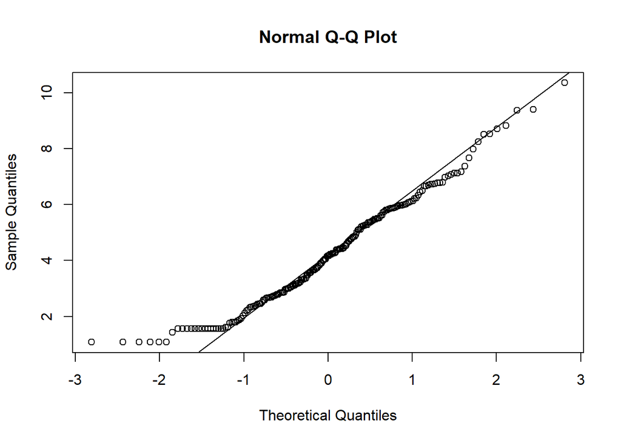

```
Call: mardia(x = data.cfa)

Mardia tests of multivariate skew and kurtosis
Use describe(x) the to get univariate tests
n.obs = 201   num.vars =  22
b1p =  229.22   skew =  7679.03  with probability  <=  0
 small sample skew =  7803.72  with probability <=  0
b2p =  841.27   kurtosis =  68.34  with probability <=  0
```

```r
mardia(data.cfa)
```

the data are not multivariate normal (`kurtosis` > 5, *P* < 0.05). We will use **MLR** in our analysis.

## 2.2 Step 1

Specify the measurement model according to `lavaan` syntax.

```r
model1 = "
PA1 =~ P1 + P2 + P3 + P4 + P5 + P6 + P7 + P8 + P9 + P16 + P17
PA2 =~ P10 + P11 + P12 + P13 + P14
PA3 =~ P15 + P18 + P19 + P20 + P21 + P22
"
```

PA1 (Teaching Practices) : P1, P2, P3, P4, P5, P6, P7, P8, P9, P16, P17 (11 item)

PA2 (Monitoring) : P10, P11, P12, P13, P14 (5 item)

PA3 (Involvement): P15, P18, P19, P20, P21, P22 (6 item)

## 2.3 Step 2

### 2.3.1 Fit the model 1

```r
cfa.model1 = cfa(model1, data = data.cfa, estimator = "MLR")
# cfa.model = cfa(model, data = data.cfa, std.lv = 1)  # factor variance = 1
summary(cfa.model1, fit.measures = T, standardized = T)
```

```
lavaan 0.6-20 ended normally after 50 iterations

  Estimator                                         ML
  Optimization method                           NLMINB
  Number of model parameters                        47

  Number of observations                           201

Model Test User Model:
                                              Standard      Scaled
  Test Statistic                               870.639     568.558
  Degrees of freedom                               206         206
  P-value (Chi-square)                           0.000       0.000
  Scaling correction factor                                  1.531
    Yuan-Bentler correction (Mplus variant)

Model Test Baseline Model:

  Test statistic                              4684.985    2787.764
  Degrees of freedom                               231         231
  P-value                                        0.000       0.000
  Scaling correction factor                                  1.681

User Model versus Baseline Model:

  Comparative Fit Index (CFI)                    0.851       0.858
  Tucker-Lewis Index (TLI)                       0.833       0.841

  Robust Comparative Fit Index (CFI)                         0.871
  Robust Tucker-Lewis Index (TLI)                            0.855

Loglikelihood and Information Criteria:

  Loglikelihood user model (H0)              -5080.465   -5080.465
  Scaling correction factor                                  2.094
      for the MLR correction
  Loglikelihood unrestricted model (H1)      -4645.146   -4645.146
  Scaling correction factor                                  1.636
      for the MLR correction

```

[output cut: 76 more lines]

```
   .P17               0.283    0.042    6.790    0.000    0.283    0.242
   .P10               0.383    0.070    5.463    0.000    0.383    0.312
   .P11               0.103    0.037    2.771    0.006    0.103    0.062
   .P12               0.137    0.049    2.787    0.005    0.137    0.075
   .P13               0.380    0.106    3.576    0.000    0.380    0.267
   .P14               0.850    0.177    4.807    0.000    0.850    0.372
   .P15               0.565    0.089    6.348    0.000    0.565    0.670
   .P18               0.602    0.109    5.537    0.000    0.602    0.441
   .P19               0.338    0.066    5.125    0.000    0.338    0.212
   .P20               0.454    0.107    4.258    0.000    0.454    0.261
   .P21               0.527    0.122    4.331    0.000    0.527    0.326
   .P22               0.587    0.119    4.935    0.000    0.587    0.401
    PA1               0.949    0.128    7.412    0.000    1.000    1.000
    PA2               0.844    0.151    5.605    0.000    1.000    1.000
    PA3               0.278    0.077    3.589    0.000    1.000    1.000
```

```r
standardizedSolution(cfa.model1)  # standardized, to view the SE of FL
```

```
   lhs op rhs est.std    se      z pvalue ci.lower ci.upper
1  PA1 =~  P1   0.714 0.038 18.830  0.000    0.639    0.788
2  PA1 =~  P2   0.838 0.036 23.244  0.000    0.767    0.908
3  PA1 =~  P3   0.843 0.038 22.275  0.000    0.769    0.917
4  PA1 =~  P4   0.864 0.034 25.054  0.000    0.796    0.932
5  PA1 =~  P5   0.842 0.037 22.596  0.000    0.769    0.915
6  PA1 =~  P6   0.824 0.033 24.742  0.000    0.758    0.889
7  PA1 =~  P7   0.812 0.030 27.424  0.000    0.754    0.871
8  PA1 =~  P8   0.734 0.035 20.700  0.000    0.665    0.804
9  PA1 =~  P9   0.764 0.046 16.701  0.000    0.674    0.853
10 PA1 =~ P16   0.863 0.027 32.005  0.000    0.811    0.916
11 PA1 =~ P17   0.871 0.024 36.525  0.000    0.824    0.917
12 PA2 =~ P10   0.829 0.038 22.048  0.000    0.756    0.903
13 PA2 =~ P11   0.969 0.012 83.317  0.000    0.946    0.991
14 PA2 =~ P12   0.962 0.014 68.235  0.000    0.934    0.990
```

[output cut: 36 more lines]

```r
parameterEstimates(cfa.model1)  # unstandardized, to view the 95% CI
```

```
   lhs op rhs   est    se      z pvalue ci.lower ci.upper
1  PA1 =~  P1 1.000 0.000     NA     NA    1.000    1.000
2  PA1 =~  P2 0.893 0.065 13.645  0.000    0.765    1.022
3  PA1 =~  P3 0.890 0.077 11.487  0.000    0.738    1.042
4  PA1 =~  P4 0.853 0.081 10.533  0.000    0.694    1.012
5  PA1 =~  P5 1.031 0.080 12.887  0.000    0.874    1.188
6  PA1 =~  P6 0.960 0.069 13.863  0.000    0.824    1.095
7  PA1 =~  P7 0.898 0.065 13.724  0.000    0.770    1.027
8  PA1 =~  P8 0.959 0.065 14.736  0.000    0.832    1.087
9  PA1 =~  P9 0.865 0.079 10.951  0.000    0.710    1.019
10 PA1 =~ P16 1.033 0.080 12.836  0.000    0.875    1.191
11 PA1 =~ P17 0.966 0.076 12.662  0.000    0.816    1.115
12 PA2 =~ P10 1.000 0.000     NA     NA    1.000    1.000
13 PA2 =~ P11 1.361 0.110 12.412  0.000    1.146    1.576
14 PA2 =~ P12 1.419 0.117 12.149  0.000    1.190    1.648
```

[output cut: 36 more lines]

Localized areas of misfit,

```r
modificationIndices(cfa.model1, sort = TRUE, minimum.value = 3.84) # find mi > |3.84|
```

```
    lhs op rhs     mi    epc sepc.lv sepc.all sepc.nox
248 P16 ~~ P17 98.676  0.257   0.257    0.823    0.823
221  P8 ~~  P9 60.762  0.358   0.358    0.582    0.582
173  P5 ~~  P6 29.729  0.178   0.178    0.430    0.430
116  P2 ~~  P3 28.948  0.134   0.134    0.428    0.428
207  P7 ~~  P9 27.572  0.179   0.179    0.400    0.400
56  PA1 =~ P15 26.282  0.438   0.427    0.465    0.465
273 P10 ~~ P13 22.785  0.140   0.140    0.368    0.368
281 P11 ~~ P12 22.755  0.161   0.161    1.355    1.355
57  PA1 =~ P18 20.106  0.413   0.402    0.344    0.344
254 P16 ~~ P15 19.523  0.149   0.149    0.337    0.337
148  P3 ~~ P14 18.039 -0.165  -0.165   -0.323   -0.323
86  PA3 =~  P8 17.042  0.764   0.403    0.316    0.316
320 P19 ~~ P20 16.892  0.188   0.188    0.479    0.479
55  PA1 =~ P14 16.420  0.332   0.323    0.214    0.214
```

[output cut: 68 more lines]

```r
residuals(cfa.model1, type="standardized") # find sr > |2.58|
```

```
$type
[1] "standardized"

$cov
        P1     P2     P3     P4     P5     P6     P7     P8     P9    P16
P1   0.000
P2   0.394  0.000
P3  -0.275  1.210  0.000
P4  -0.500  0.317  0.410  0.000
P5  -0.125 -0.105  0.415  0.414  0.000
P6   0.060  0.162  0.227  0.334  1.035  0.000
P7   0.623 -0.155 -0.246 -0.416 -0.262 -0.565  0.000
P8   1.550 -0.395 -0.240 -0.941 -0.884 -0.887  1.094  0.000
P9   0.101 -0.509 -0.877 -0.301 -0.582 -0.215  1.289  2.052  0.000
P16 -0.221 -0.335 -0.457 -0.059 -0.368 -0.552  0.022 -0.105 -0.212  0.000
P17 -0.442 -0.302 -0.523 -0.144 -0.144 -0.141 -0.007 -0.383 -0.220  1.253
P10 -0.734 -0.532  0.787  0.285  0.144  1.343 -0.129  0.497  0.093 -0.283
P11 -0.520 -0.734  0.538  0.025 -0.005  0.665 -0.286  0.271  0.029 -0.587
P12 -0.883 -0.625  0.567  0.207 -0.113  0.751 -0.240  0.471  0.250 -0.683
P13 -0.425 -0.439 -0.297 -0.301 -0.568  1.206 -0.553 -0.100  0.125 -0.435
P14  1.281  1.218  0.733  1.568  2.166  2.263  0.807  1.050  1.205  1.396
P15  0.122  1.123  0.738  1.390  0.320  1.221  2.234  2.506  2.387  3.531
P18  1.771  1.252  1.325  1.068  1.354  1.441  1.064  2.044  1.655  2.311
P19  0.456 -0.287 -1.213 -1.086 -1.448 -1.094 -0.267  0.937  0.002  0.265
P20  0.014 -1.732 -1.593 -1.594 -1.642 -1.291 -0.313  1.866  1.034 -0.049
P21 -0.545 -1.353 -1.742 -1.177 -1.234 -0.977 -0.357  1.458  1.216  0.250
P22  0.729 -0.193 -0.629  0.360  0.671  0.806  1.286  2.638  3.117  0.783
       P17    P10    P11    P12    P13    P14    P15    P18    P19    P20
P1
P2
P3
P4
P5
P6
P7
P8
P9
P16
P17  0.000
P10 -0.438  0.000
```

[output cut: 18 more lines]

```
P8
P9
P16
P17
P10
P11
P12
P13
P14
P15
P18
P19
P20
P21  0.000
P22  0.346  0.000
```

## 2.4 Step 3

### 2.4.1 Refine Model 2

```r
# Step 1: Add strongest correlated residuals
model2 <- '
  PA1 =~ P1 + P2 + P3 + P4 + P5 + P6 + P7 + P8 + P9 + P16 + P17
  PA2 =~ P10 + P11 + P12 + P13 + P14
  PA3 =~ P15 + P18 + P19 + P20 + P21 + P22

  # Correlated residuals (theoretically justified)
  P16 ~~ P17
'


cfa.model2 = cfa(model2, data = data.cfa, estimator = "MLR")
# cfa.model = cfa(model, data = data.cfa, std.lv = 1)  # factor variance = 1
summary(cfa.model2, fit.measures = T, standardized = T)
```

```
lavaan 0.6-20 ended normally after 56 iterations

  Estimator                                         ML
  Optimization method                           NLMINB
  Number of model parameters                        48

  Number of observations                           201

Model Test User Model:
                                              Standard      Scaled
  Test Statistic                               765.406     500.439
  Degrees of freedom                               205         205
  P-value (Chi-square)                           0.000       0.000
  Scaling correction factor                                  1.529
    Yuan-Bentler correction (Mplus variant)

Model Test Baseline Model:

  Test statistic                              4684.985    2787.764
  Degrees of freedom                               231         231
  P-value                                        0.000       0.000
  Scaling correction factor                                  1.681

User Model versus Baseline Model:

  Comparative Fit Index (CFI)                    0.874       0.884
  Tucker-Lewis Index (TLI)                       0.858       0.870

  Robust Comparative Fit Index (CFI)                         0.895
  Robust Tucker-Lewis Index (TLI)                            0.881

Loglikelihood and Information Criteria:

  Loglikelihood user model (H0)              -5027.849   -5027.849
  Scaling correction factor                                  2.090
      for the MLR correction
  Loglikelihood unrestricted model (H1)      -4645.146   -4645.146
  Scaling correction factor                                  1.636
      for the MLR correction

```

[output cut: 78 more lines]

```
   .P17               0.347    0.047    7.425    0.000    0.347    0.297
   .P10               0.383    0.070    5.462    0.000    0.383    0.312
   .P11               0.103    0.037    2.776    0.005    0.103    0.062
   .P12               0.137    0.049    2.785    0.005    0.137    0.074
   .P13               0.380    0.106    3.574    0.000    0.380    0.267
   .P14               0.850    0.177    4.809    0.000    0.850    0.372
   .P15               0.569    0.089    6.377    0.000    0.569    0.674
   .P18               0.604    0.109    5.554    0.000    0.604    0.443
   .P19               0.335    0.065    5.120    0.000    0.335    0.210
   .P20               0.450    0.106    4.257    0.000    0.450    0.258
   .P21               0.527    0.122    4.334    0.000    0.527    0.326
   .P22               0.588    0.119    4.926    0.000    0.588    0.402
    PA1               0.960    0.129    7.443    0.000    1.000    1.000
    PA2               0.844    0.151    5.604    0.000    1.000    1.000
    PA3               0.275    0.076    3.599    0.000    1.000    1.000
```

```r
modificationIndices(cfa.model2, sort = TRUE, minimum.value = 3.84) # find mi > |3.84|
```

```
    lhs op rhs     mi    epc sepc.lv sepc.all sepc.nox
222  P8 ~~  P9 61.224  0.361   0.361    0.589    0.589
208  P7 ~~  P9 28.224  0.183   0.183    0.409    0.409
174  P5 ~~  P6 26.016  0.164   0.164    0.413    0.413
117  P2 ~~  P3 23.840  0.119   0.119    0.401    0.401
273 P10 ~~ P13 22.792  0.140   0.140    0.368    0.368
281 P11 ~~ P12 22.424  0.159   0.159    1.343    1.343
57  PA1 =~ P15 21.601  0.389   0.381    0.415    0.415
58  PA1 =~ P18 19.396  0.397   0.389    0.333    0.333
87  PA3 =~  P8 18.553  0.788   0.413    0.325    0.325
159  P4 ~~  P8 17.329 -0.136  -0.136   -0.329   -0.329
149  P3 ~~ P14 17.277 -0.157  -0.157   -0.320   -0.320
74  PA2 =~ P15 16.390  0.278   0.256    0.279    0.279
207  P7 ~~  P8 16.364  0.168   0.168    0.309    0.309
142  P3 ~~  P9 16.216 -0.120  -0.120   -0.318   -0.318
```

[output cut: 68 more lines]

```r
residuals(cfa.model2, type="standardized") # find sr > |2.58|
```

```
$type
[1] "standardized"

$cov
        P1     P2     P3     P4     P5     P6     P7     P8     P9    P16
P1   0.000
P2   0.311  0.000
P3  -0.480  1.064  0.000
P4  -0.640  0.218  0.340  0.000
P5  -0.245 -0.263  0.318  0.379  0.000
P6  -0.066  0.013  0.020  0.236  0.998  0.000
P7   0.634 -0.224 -0.349 -0.471 -0.338 -0.671  0.000
P8   1.549 -0.514 -0.370 -1.063 -1.044 -1.022  1.132  0.000
P9   0.057 -0.629 -1.031 -0.372 -0.699 -0.310  1.342  2.054  0.000
P16  0.029 -0.106 -0.290  0.194 -0.156 -0.346  0.294  0.132  0.033  0.000
P17 -0.210 -0.091 -0.344  0.096  0.044  0.057  0.257 -0.138  0.008  0.000
P10 -0.827 -0.648  0.692  0.216  0.055  1.287 -0.181  0.440  0.026 -0.178
P11 -0.646 -0.905  0.433 -0.064 -0.124  0.576 -0.357  0.201 -0.055 -0.464
P12 -1.011 -0.789  0.464  0.128 -0.233  0.666 -0.310  0.402  0.169 -0.571
P13 -0.510 -0.533 -0.423 -0.397 -0.703  1.154 -0.624 -0.155  0.072 -0.369
P14  1.203  1.115  0.650  1.526  2.107  2.170  0.773  1.003  1.123  1.564
P15  0.175  1.169  0.747  1.432  0.355  1.244  2.321  2.597  2.474  3.958
P18  1.821  1.296  1.354  1.159  1.407  1.493  1.199  2.130  1.746  2.753
P19  0.525 -0.230 -1.248 -1.047 -1.445 -1.071 -0.141  1.017  0.089  0.635
P20  0.069 -1.688 -1.673 -1.602 -1.668 -1.280 -0.212  1.993  1.141  0.299
P21 -0.476 -1.284 -1.773 -1.134 -1.215 -0.930 -0.245  1.550  1.316  0.594
P22  0.797 -0.142 -0.617  0.455  0.732  0.861  1.425  2.752  3.271  1.150
       P17    P10    P11    P12    P13    P14    P15    P18    P19    P20
P1
P2
P3
P4
P5
P6
P7
P8
P9
P16
P17  0.000
P10 -0.353  0.000
```

[output cut: 18 more lines]

```
P8
P9
P16
P17
P10
P11
P12
P13
P14
P15
P18
P19
P20
P21  0.000
P22  0.334  0.000
```

### 2.4.2 Refine Model 3

```r
model3 <- '
  # Factors
  PA1 =~ P1 + P2 + P3 + P4 + P5 + P6 + P7 + P8 + P9 + P16 + P17
  PA2 =~ P10 + P11 + P12 + P13 + P14
  PA3 =~ P15 + P18 + P19 + P20 + P21 + P22

  # Correlated residuals (theoretically justified)
  P16 ~~ P17
  P8 ~~ P9
  '

cfa.model3 = cfa(model3, data = data.cfa, estimator = "MLR")
# cfa.model = cfa(model, data = data.cfa, std.lv = 1)  # factor variance = 1
summary(cfa.model3, fit.measures = T, standardized = T)
```

```
lavaan 0.6-20 ended normally after 60 iterations

  Estimator                                         ML
  Optimization method                           NLMINB
  Number of model parameters                        49

  Number of observations                           201

Model Test User Model:
                                              Standard      Scaled
  Test Statistic                               697.064     456.814
  Degrees of freedom                               204         204
  P-value (Chi-square)                           0.000       0.000
  Scaling correction factor                                  1.526
    Yuan-Bentler correction (Mplus variant)

Model Test Baseline Model:

  Test statistic                              4684.985    2787.764
  Degrees of freedom                               231         231
  P-value                                        0.000       0.000
  Scaling correction factor                                  1.681

User Model versus Baseline Model:

  Comparative Fit Index (CFI)                    0.889       0.901
  Tucker-Lewis Index (TLI)                       0.875       0.888

  Robust Comparative Fit Index (CFI)                         0.910
  Robust Tucker-Lewis Index (TLI)                            0.898

Loglikelihood and Information Criteria:

  Loglikelihood user model (H0)              -4993.678   -4993.678
  Scaling correction factor                                  2.093
      for the MLR correction
  Loglikelihood unrestricted model (H1)      -4645.146   -4645.146
  Scaling correction factor                                  1.636
      for the MLR correction

```

[output cut: 80 more lines]

```
   .P17               0.348    0.048    7.324    0.000    0.348    0.298
   .P10               0.383    0.070    5.462    0.000    0.383    0.312
   .P11               0.103    0.037    2.777    0.005    0.103    0.062
   .P12               0.137    0.049    2.783    0.005    0.137    0.074
   .P13               0.380    0.106    3.573    0.000    0.380    0.267
   .P14               0.850    0.177    4.808    0.000    0.850    0.372
   .P15               0.570    0.089    6.377    0.000    0.570    0.676
   .P18               0.605    0.109    5.539    0.000    0.605    0.443
   .P19               0.332    0.065    5.118    0.000    0.332    0.208
   .P20               0.449    0.106    4.228    0.000    0.449    0.258
   .P21               0.527    0.122    4.329    0.000    0.527    0.326
   .P22               0.590    0.120    4.930    0.000    0.590    0.403
    PA1               0.944    0.129    7.317    0.000    1.000    1.000
    PA2               0.844    0.151    5.604    0.000    1.000    1.000
    PA3               0.273    0.076    3.599    0.000    1.000    1.000
```

```r
modificationIndices(cfa.model3, sort = TRUE, minimum.value = 3.84) # find mi > |3.84|
```

```
    lhs op rhs     mi    epc sepc.lv sepc.all sepc.nox
273 P10 ~~ P13 22.783  0.140   0.140    0.368    0.368
281 P11 ~~ P12 22.555  0.160   0.160    1.346    1.346
175  P5 ~~  P6 21.912  0.146   0.146    0.386    0.386
58  PA1 =~ P15 20.801  0.378   0.367    0.400    0.400
118  P2 ~~  P3 20.562  0.108   0.108    0.379    0.379
59  PA1 =~ P18 20.555  0.403   0.392    0.335    0.335
150  P3 ~~ P14 19.413 -0.164  -0.164   -0.341   -0.341
200  P6 ~~ P13 16.674  0.121   0.121    0.317    0.317
75  PA2 =~ P15 16.449  0.279   0.256    0.279    0.279
103  P1 ~~  P8 15.825  0.207   0.207    0.241    0.241
320 P19 ~~ P20 15.417  0.181   0.181    0.467    0.467
209  P7 ~~  P9 14.876  0.115   0.115    0.240    0.240
57  PA1 =~ P14 14.837  0.319   0.310    0.205    0.205
305 P14 ~~ P15 14.026  0.192   0.192    0.275    0.275
```

[output cut: 56 more lines]

```r
residuals(cfa.model3, type="standardized") # find sr > |2.58|
```

```
$type
[1] "standardized"

$cov
        P1     P2     P3     P4     P5     P6     P7     P8     P9    P16
P1   0.000
P2   0.337  0.000
P3  -0.476  0.915  0.000
P4  -0.634  0.090  0.246  0.000
P5  -0.255 -0.383  0.211  0.269  0.000
P6  -0.058 -0.097 -0.121  0.088  0.864  0.000
P7   0.804 -0.141 -0.306 -0.431 -0.307 -0.603  0.000
P8   1.828 -0.238 -0.176 -0.861 -0.819 -0.730  1.525  0.000
P9   0.330 -0.431 -0.854 -0.200 -0.576 -0.156  1.703  0.000  0.000
P16  0.105 -0.121 -0.323  0.151 -0.203 -0.372  0.394  0.371  0.244  0.000
P17 -0.142 -0.121 -0.395  0.038 -0.019  0.009  0.347  0.099  0.206  0.000
P10 -0.784 -0.664  0.668  0.188  0.021  1.276 -0.111  0.604  0.169 -0.159
P11 -0.594 -0.934  0.407 -0.098 -0.169  0.561 -0.268  0.388  0.122 -0.439
P12 -0.960 -0.815  0.437  0.095 -0.276  0.652 -0.220  0.598  0.341 -0.545
P13 -0.473 -0.539 -0.448 -0.426 -0.742  1.137 -0.557 -0.031  0.189 -0.351
P14  1.252  1.089  0.625  1.502  2.075  2.153  0.836  1.203  1.236  1.574
P15  0.271  1.237  0.786  1.474  0.388  1.295  2.497  2.901  2.793  4.135
P18  1.977  1.398  1.444  1.258  1.473  1.565  1.411  2.626  2.108  2.909
P19  0.686 -0.113 -1.176 -0.968 -1.401 -0.984  0.082  1.443  0.398  0.756
P20  0.220 -1.577 -1.627 -1.563 -1.641 -1.188 -0.017  2.326  1.411  0.430
P21 -0.320 -1.180 -1.768 -1.097 -1.199 -0.867 -0.057  1.838  1.590  0.730
P22  0.959 -0.049 -0.548  0.531  0.791  0.936  1.625  3.257  3.681  1.273
       P17    P10    P11    P12    P13    P14    P15    P18    P19    P20
P1
P2
P3
P4
P5
P6
P7
P8
P9
P16
P17  0.000
P10 -0.340  0.000
```

[output cut: 18 more lines]

```
P8
P9
P16
P17
P10
P11
P12
P13
P14
P15
P18
P19
P20
P21  0.000
P22  0.364  0.000
```

### 2.4.3 Refine Model 4

```r
model4 <- '
  # Factors
  PA1 =~ P1 + P2 + P3 + P4 + P5 + P6 + P7 + P8 + P9 + P16 + P17
  PA2 =~ P10 + P11 + P12 + P13 + P14
  PA3 =~ P18 + P19 + P20 + P21 + P22

  # Correlated residuals (theoretically justified)
  P16 ~~ P17
  P8 ~~ P9
  '

cfa.model4 = cfa(model4, data = data.cfa, estimator = "MLR")
# cfa.model = cfa(model, data = data.cfa, std.lv = 1)  # factor variance = 1
summary(cfa.model4, fit.measures = T, standardized = T)
```

```
lavaan 0.6-20 ended normally after 51 iterations

  Estimator                                         ML
  Optimization method                           NLMINB
  Number of model parameters                        47

  Number of observations                           201

Model Test User Model:
                                              Standard      Scaled
  Test Statistic                               566.976     367.871
  Degrees of freedom                               184         184
  P-value (Chi-square)                           0.000       0.000
  Scaling correction factor                                  1.541
    Yuan-Bentler correction (Mplus variant)

Model Test Baseline Model:

  Test statistic                              4483.773    2621.726
  Degrees of freedom                               210         210
  P-value                                        0.000       0.000
  Scaling correction factor                                  1.710

User Model versus Baseline Model:

  Comparative Fit Index (CFI)                    0.910       0.924
  Tucker-Lewis Index (TLI)                       0.898       0.913

  Robust Comparative Fit Index (CFI)                         0.931
  Robust Tucker-Lewis Index (TLI)                            0.922

Loglikelihood and Information Criteria:

  Loglikelihood user model (H0)              -4761.180   -4761.180
  Scaling correction factor                                  2.115
      for the MLR correction
  Loglikelihood unrestricted model (H1)      -4477.692   -4477.692
  Scaling correction factor                                  1.658
      for the MLR correction

```

[output cut: 78 more lines]

```
   .P16               0.432    0.059    7.296    0.000    0.432    0.318
   .P17               0.350    0.048    7.310    0.000    0.350    0.300
   .P10               0.383    0.070    5.463    0.000    0.383    0.312
   .P11               0.102    0.037    2.778    0.005    0.102    0.062
   .P12               0.137    0.049    2.786    0.005    0.137    0.075
   .P13               0.380    0.106    3.572    0.000    0.380    0.268
   .P14               0.851    0.177    4.809    0.000    0.851    0.372
   .P18               0.613    0.112    5.485    0.000    0.613    0.449
   .P19               0.309    0.064    4.808    0.000    0.309    0.194
   .P20               0.431    0.105    4.086    0.000    0.431    0.248
   .P21               0.533    0.121    4.396    0.000    0.533    0.330
   .P22               0.597    0.124    4.837    0.000    0.597    0.408
    PA1               0.944    0.129    7.316    0.000    1.000    1.000
    PA2               0.844    0.151    5.603    0.000    1.000    1.000
    PA3               0.752    0.144    5.237    0.000    1.000    1.000
```

```r
modificationIndices(cfa.model4, sort = TRUE, minimum.value = 3.84) # find mi > |3.84|
```

```
    lhs op rhs     mi    epc sepc.lv sepc.all sepc.nox
56  PA1 =~ P18 23.838  0.424   0.413    0.353    0.353
258 P10 ~~ P13 22.818  0.140   0.140    0.368    0.368
265 P11 ~~ P12 22.155  0.158   0.158    1.338    1.338
167  P5 ~~  P6 21.667  0.145   0.145    0.384    0.384
113  P2 ~~  P3 20.293  0.107   0.107    0.377    0.377
144  P3 ~~ P14 19.398 -0.163  -0.163   -0.341   -0.341
191  P6 ~~ P13 16.796  0.121   0.121    0.318    0.318
99   P1 ~~  P8 15.861  0.207   0.207    0.241    0.241
199  P7 ~~  P9 14.957  0.116   0.116    0.240    0.240
55  PA1 =~ P14 14.738  0.318   0.309    0.204    0.204
137  P3 ~~  P9 11.535 -0.084  -0.084   -0.218   -0.218
128  P2 ~~ P19 11.182  0.091   0.091    0.301    0.301
153  P4 ~~  P8 11.160 -0.090  -0.090   -0.215   -0.215
235  P9 ~~ P22 10.845  0.118   0.118    0.206    0.206
```

[output cut: 47 more lines]

```r
residuals(cfa.model4, type="standardized") # find sr > |2.58|
```

```
$type
[1] "standardized"

$cov
        P1     P2     P3     P4     P5     P6     P7     P8     P9    P16
P1   0.000
P2   0.341  0.000
P3  -0.527  1.020  0.000
P4  -0.674  0.095  0.327  0.000
P5  -0.265 -0.394  0.238  0.314  0.000
P6  -0.065 -0.116 -0.157  0.099  0.898  0.000
P7   0.869 -0.173 -0.443 -0.647 -0.379 -0.737  0.000
P8   1.925 -0.267 -0.203 -1.044 -0.861 -0.840  2.000  0.000
P9   0.353 -0.479 -0.982 -0.225 -0.590 -0.166  2.109  0.000  0.000
P16  0.122 -0.140 -0.418  0.215 -0.219 -0.456  0.597  0.499  0.329  0.000
P17 -0.144 -0.135 -0.494  0.055 -0.018  0.017  0.493  0.139  0.262  0.000
P10 -0.773 -0.642  0.782  0.221  0.021  1.316 -0.120  0.634  0.177 -0.166
P11 -0.595 -0.941  0.534 -0.134 -0.217  0.608 -0.340  0.423  0.134 -0.506
P12 -0.948 -0.818  0.543  0.126 -0.328  0.705 -0.273  0.649  0.364 -0.615
P13 -0.513 -0.625 -0.531 -0.514 -0.838  1.437 -0.682 -0.032  0.222 -0.434
P14  1.454  1.388  0.774  2.094  2.750  2.953  1.111  1.472  1.513  2.232
P18  2.341  1.646  1.715  1.437  1.646  1.773  1.746  3.007  2.398  3.376
P19  0.878  0.046 -1.198 -0.905 -1.377 -0.889  0.247  1.680  0.550  0.984
P20  0.367 -1.497 -1.648 -1.584 -1.644 -1.075  0.124  2.610  1.647  0.661
P21 -0.178 -1.004 -1.704 -0.999 -1.074 -0.698  0.131  2.126  1.914  1.084
P22  1.193  0.136 -0.382  0.722  0.984  1.116  1.921  3.515  3.984  1.526
       P17    P10    P11    P12    P13    P14    P18    P19    P20    P21
P1
P2
P3
P4
P5
P6
P7
P8
P9
P16
P17  0.000
P10 -0.355  0.000
P11 -0.353 -0.032  0.000
```

[output cut: 15 more lines]

```
P7
P8
P9
P16
P17
P10
P11
P12
P13
P14
P18
P19
P20
P21
P22  0.000
```

# 3 Comparing the Models

```r
# Grab key measures
want <- c(  "chisq.scaled", "df", "cfi.scaled", "tli.scaled", "rmsea.scaled", "rmsea.ci.lower.scaled", "rmsea.ci.upper.scaled",  "srmr")

fm1 <- fitMeasures(cfa.model1, fit.measures = want)
fm2 <- fitMeasures(cfa.model2, fit.measures = want)
fm3 <- fitMeasures(cfa.model3, fit.measures = want)
fm4 <- fitMeasures(cfa.model4, fit.measures = want)

comp <- rbind(
  Model1 = fm1,
  Model2 = fm2,
  Model3 = fm3,
  Model4 = fm4,
  Delta  = fm1 - fm4)
round(comp, 3)
```

```
       chisq.scaled  df cfi.scaled tli.scaled rmsea.scaled
Model1      568.558 206      0.858      0.841        0.094
Model2      500.439 205      0.884      0.870        0.085
Model3      456.814 204      0.901      0.888        0.079
Model4      367.871 184      0.924      0.913        0.071
Delta       200.688  22     -0.066     -0.072        0.023
       rmsea.ci.lower.scaled rmsea.ci.upper.scaled  srmr
Model1                 0.086                 0.101 0.082
Model2                 0.077                 0.092 0.083
Model3                 0.071                 0.086 0.084
Model4                 0.062                 0.079 0.071
Delta                  0.024                 0.022 0.011
```

```r
anova(cfa.model1, cfa.model4)   # lavaan will use the Satorra–Bentler scaled test when robust estimators are used
```

```
Scaled Chi-Squared Difference Test (method = "satorra.bentler.2001")

lavaan->lavTestLRT():
   lavaan NOTE: The "Chisq" column contains standard test statistics, not the
   robust test that should be reported per model. A robust difference test is
   a function of two standard (not robust) statistics.

            Df     AIC     BIC  Chisq Chisq diff   RMSEA Df diff Pr(>Chisq)
cfa.model4 184  9616.4  9771.6 566.98
cfa.model1 206 10254.9 10410.2 870.64     209.67 0.24792      22  < 2.2e-16 ***
---
Signif. codes:  0 '***' 0.001 '**' 0.01 '*' 0.05 '.' 0.1 ' ' 1
```

# 4 Composite reliability

```r
compRelSEM(cfa.model4)
```

```
  PA1   PA2   PA3
0.938 0.942 0.916
```

# 5 Path diagram

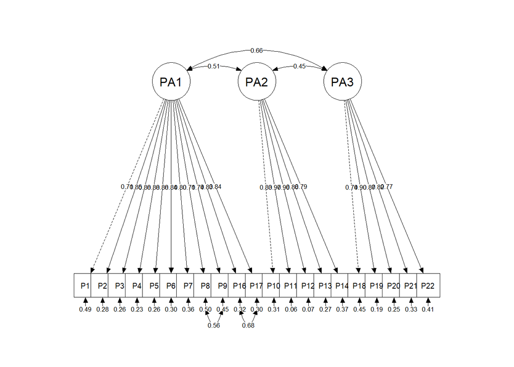

```r
semPaths(cfa.model4, 'path', 'std', style = 'lisrel',
         edge.color = 'black')
```